# Méthodes de Partionnement et d'apprentissage non supervisé

# L'algorithme

## étape 1 :

- $k$ centres provisoires tirés au hasard
- $k$ clusters créés à partir des centres en regroupant les individus les plus proches de chaque centre
- obtention de la partition $P_0$

## Choix des centres provisoires

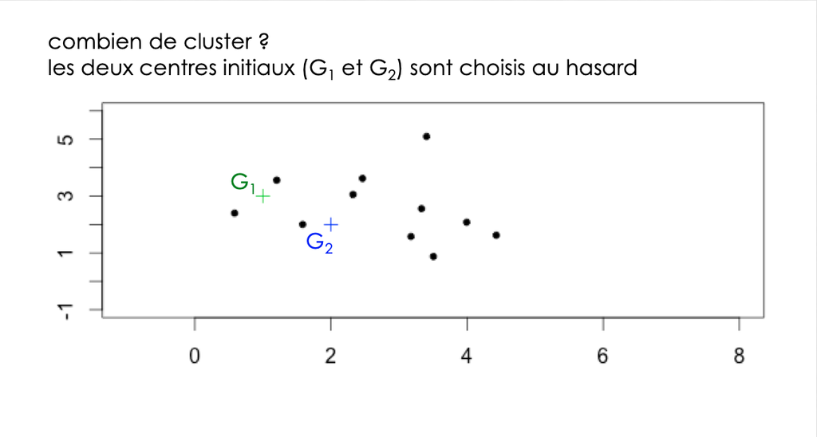

## Calcul des distances aux centres provisoires

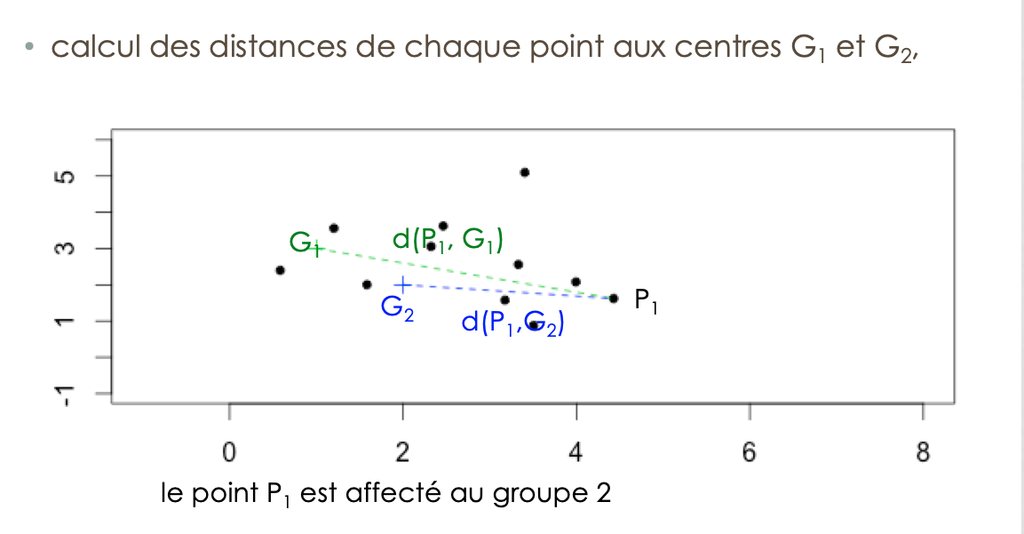

## Affectation à un cluster

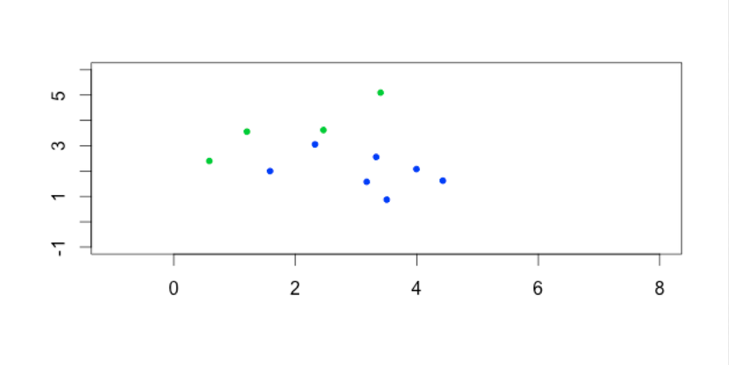

## Calcul des nouveaux centres de classes

## Etape j :

- construction des centres de gravité des k clusters construits à l’étape $(j-1)$
- $k$ nouveaux clusters créés à partir des nouveaux centres suivant la même règle qu’à l’étape $0$
- obtention de la partition $P_j$

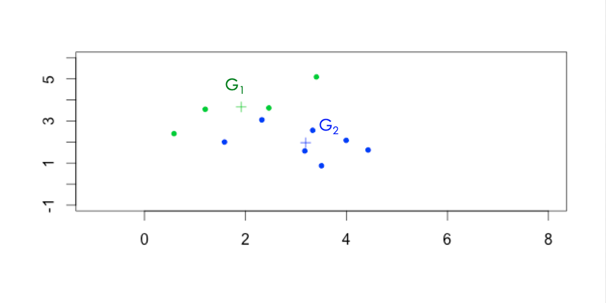

## Fin :

- l’algorithme converge vers une partition stable

## Arrêt :

- lorsque la partition reste la même, ou lorsque la variance intra-cluster ne décroit plus, ou lorsque le nombre maximal d’itérations est atteint.

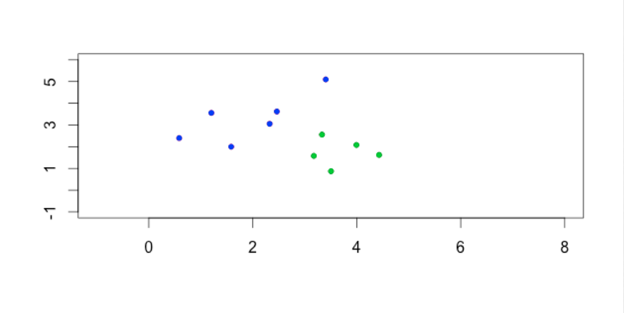

## Un premier k-means en 5 groupes

```r
iris.scale.kmeans5 <- kmeans(mes.iris.scaled, center=5)
iris.scale.kmeans5
```

```
K-means clustering with 5 clusters of sizes 23, 11, 38, 62, 16

Cluster means:
  Sepal.Length Sepal.Width Petal.Length Petal.Width
1  -0.89550725  0.30788406   -2.2797391  -0.9558551
2  -1.26151515 -0.06642424   -2.4125455  -0.9993333
3   1.00666667  0.01635088    1.9841053   0.8717193
4   0.05827957 -0.30894624    0.6355484   0.2345376
5  -0.46208333  0.76141667   -2.2392500  -0.9180833

Clustering vector:
  [1] 1 2 2 2 1 5 1 1 2 1 5 1 2 2 5 5 5 1 5 5 5 5 1 1 1 1 1 1 1 1 1 5 5 5 1 1 5 1 2 1 1 2 2 1 5 2 5 2 5 1 4 4 3 4 4 4 4 4 4 4 4 4 4 4 4 4 4 4 4 4 4 4 4 4 4 4 4 3 4 4 4 4 4 4 4 4 4 4 4 4 4 4 4 4 4 4 4 4 4 4 3 4 3 3 3 3 4 3 3 3 3 3 3 4 4 3 3 3 3 4 3 4 3 4 3 3 4 4 3 3 3 3 3 4 3 3 3 3 4 3 3 3 4 3 3 3 4
[148] 3 3 4

Within cluster sum of squares by cluster:
[1]  2.285217  1.172727 23.879474 39.820968  2.497500
 (between_SS / total_SS =  89.8 %)

Available components:

[1] "cluster"      "centers"      "totss"        "withinss"     "tot.withinss" "betweenss"    "size"         "iter"         "ifault"
```

```r
iris.scale.kmeans5$cluster
```

```
  [1] 1 2 2 2 1 5 1 1 2 1 5 1 2 2 5 5 5 1 5 5 5 5 1 1 1 1 1 1 1 1 1 5 5 5 1 1 5 1 2 1 1 2 2 1 5 2 5 2 5 1 4 4 3 4 4 4 4 4 4 4 4 4 4 4 4 4 4 4 4 4 4 4 4 4 4 4 4 3 4 4 4 4 4 4 4 4 4 4 4 4 4 4 4 4 4 4 4 4 4 4 3 4 3 3 3 3 4 3 3 3 3 3 3 4 4 3 3 3 3 4 3 4 3 4 3 3 4 4 3 3 3 3 3 4 3 3 3 3 4 3 3 3 4 3 3 3 4
[148] 3 3 4
```

```r
table(iris.scale.kmeans5$cluster)
```

```
 1  2  3  4  5
23 11 38 62 16
```

## Visualisation des clusters

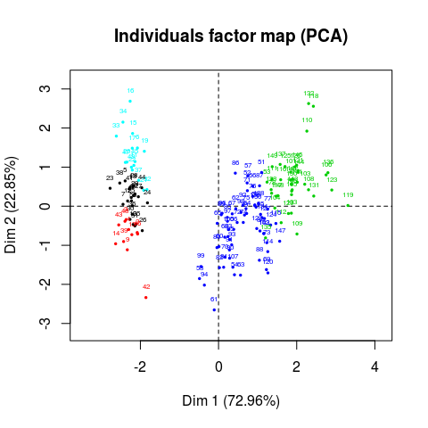

```r
plot(iris.scaled.acp, col.ind = iris.scale.kmeans5$cluster, choix = "ind", cex = 0.5)
```

## Combien de clusters ?

Quand une partition est-elle bonne ?

- si les individus d’un même cluster sont proches
  - homogénéité maximale à l’intérieur de chaque cluster
- si les individus de 2 clusters différents sont éloignés
  - hétérogénéité maximale entre chaque cluster

## Classification hiérarchique

La coupure de l’arbre à un niveau donné construit une partition. la coupure doit se faire :

- après les agrégations correspondant à des valeurs peu élevées de l’indice
- avant les agrégations correspondant à des niveaux élevés de l’indice, qui dissocient les groupes bien distincts dans la population.

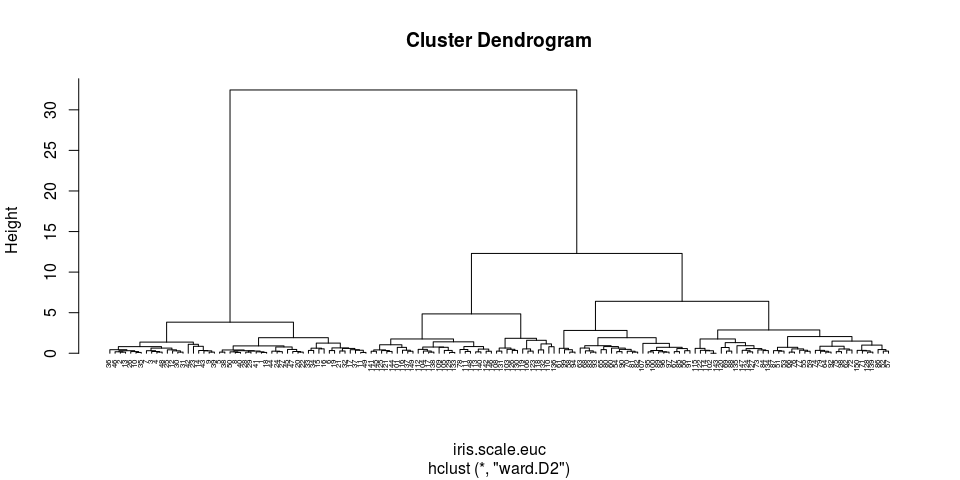

```r
plot(iris.scale.hclust.ward, hang=-1, cex=0.5)
```

## K-means

```r
I.intra = numeric(length=10)
I.intra[1] = kmeans(mes.iris.scaled, centers=2)$totss
for (i in 2:10) {
  kmi <- kmeans(mes.iris.scaled, centers=i)
  I.intra[i] <- kmi$tot.withinss
}
```

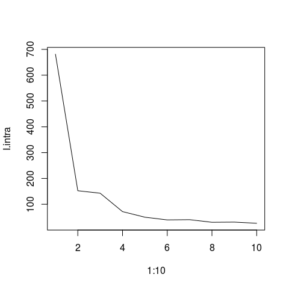

```r
plot(1:10, I.intra, type="l")
```

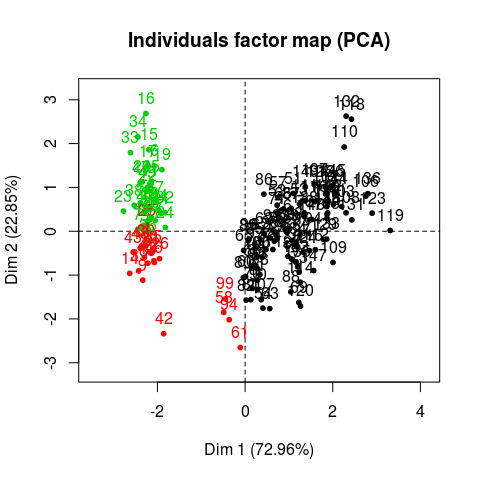

```r
iris.scale.kmeans3 <- kmeans(mes.iris.scaled, center=3)
plot(iris.scaled.acp, col.ind=iris.scale.kmeans3$cluster, choix="ind")
```

# Heatmap

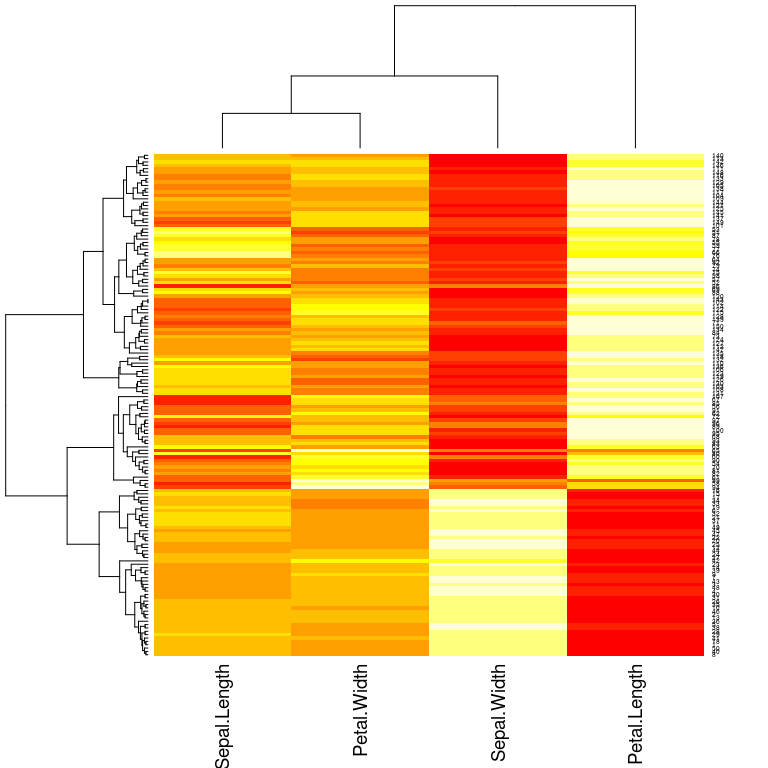

```r
heatmap(mes.iris.scaled, margins = c(7,4), cexCol = 1.4, cexRow = 0.5)
```

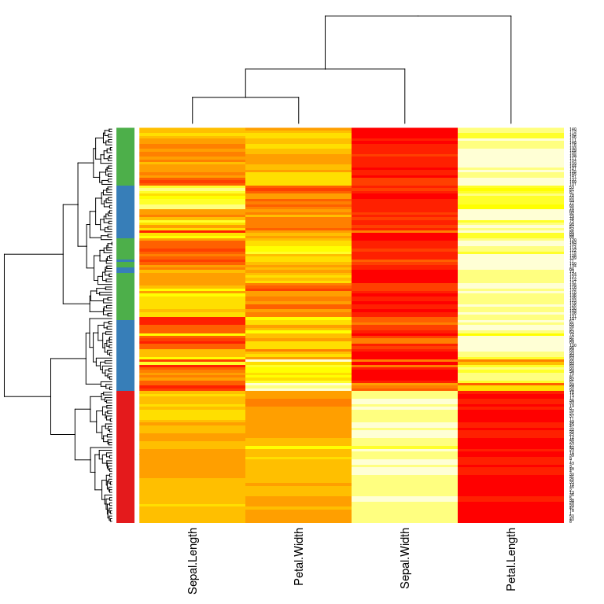

```r
my_group <- as.numeric(as.factor(substr(variete, 1 , 2)))
my_col <- brewer.pal(3, "Set1")[my_group]
heatmap(mes.iris.scaled, RowSideColors = my_col,
        margins = c(7,4), cexCol = 1.4, cexRow = 0.5)
```

# Comparaison de clustering: Rand Index

Mesure de similarité entre deux clustering

à partir du nombre de fois que les classifications sont d'accord

$$R=\frac{m+s}{t}$$

- m=nombre de paires dans la même classe dans les deux classifications
- s=nombre de paires séparées dans les deux classifications
- t=nombre de paires totales

# Comparaison de clustering: Adjusted Rand Index

$$ARI=\frac{RI-Expected RI}{Max RI -Expected RI}$$

- ARI=RI normalisé
- Prend en compte la taille des classes
- ARI=1 pour classification identique
- ARI $\simeq$ 0 pour classification aléatoire (peut être <0)
- Adapté pour nombre de classe différent entre les deux classifications et taille de classe différente

# Comparaison des résultats des deux classifications

- par une table de confusion

```r
cluster.kmeans3 <- iris.scale.kmeans3$cluster
cluster.hclust5 <- cutree(iris.scale.hclust.ward, k=5)
table(cluster.hclust5, cluster.kmeans3)
```

```
               cluster.kmeans3
cluster.hclust5  1  2  3
              1  0 17 33
              2 38  0  0
              3 22  4  0
              4 24  0  0
              5 12  0  0
```

- par une visualisation

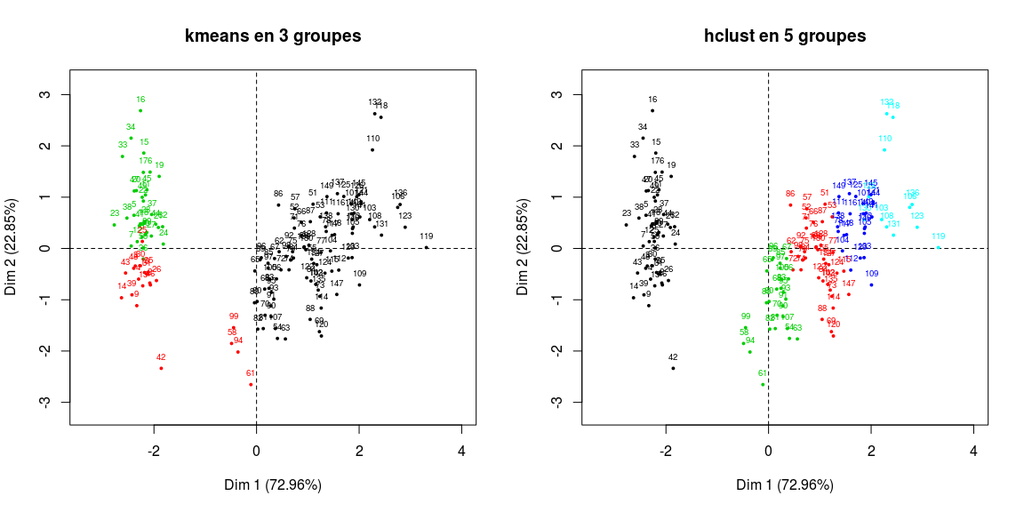

```r
par(mfrow=c(1,2))
plot(iris.scaled.acp, col.ind=cluster.kmeans3, choix="ind", title="kmeans en 3 groupes", cex=0.6)
plot(iris.scaled.acp, col.ind=cluster.hclust5, choix="ind", title="hclust en 5 groupes", cex=0.6)
```

```r
par(mfrow=c(1,1))
```

# Comparaison avec la réalité

## La réalité

```r
variete <- iris[,5]
table(variete)
```

```
variete
    setosa versicolor  virginica
        50         50         50
```

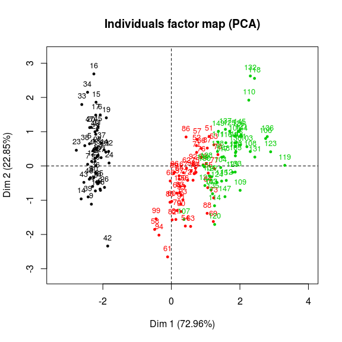

```r
plot(iris.scaled.acp, col.ind=variete, choix="ind", cex=0.8)
```

# Comparer k-means avec la réalité

```r
conf.kmeans <- table(variete, cluster.kmeans3)
kable(conf.kmeans, caption = "Confusion table: 3-clusters k-means versus actual class")
```

Confusion table: 3-clusters k-means versus actual class

|  | 1 | 2 | 3 |
| --- | --- | --- | --- |
| setosa | 0 | 17 | 33 |
| versicolor | 46 | 4 | 0 |
| virginica | 50 | 0 | 0 |

## Setosa vs others

### Visualisation

```r
variete2 <- rep("notSetosa", 150)
variete2[variete=="setosa"] <- "setosa"
variete2 = factor(variete2)
table(variete2)
```

```
variete2
notSetosa    setosa
      100        50
```

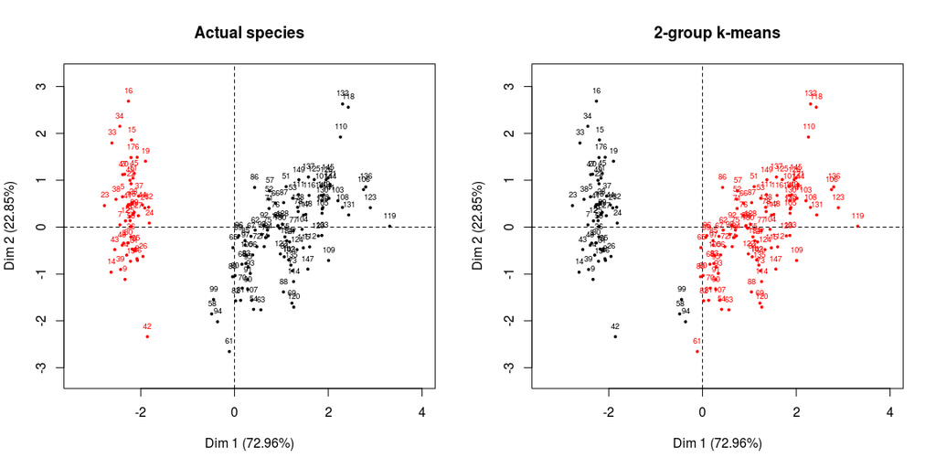

```r
par(mfrow=c(1,2))
plot(iris.scaled.acp, col.ind=variete2, title="Actual species", cex=0.6)
cluster.kmeans2 <- kmeans(mes.iris.scaled, center=2)$cluster
plot(iris.scaled.acp, col.ind=cluster.kmeans2, title="2-group k-means", cex=0.6)
```

```r
par(mfrow=c(1,1))
```

### Table de confusion et calcul de performances

```r
conf.kmeans <- table(variete2, cluster.kmeans2)
kable(conf.kmeans)
```

|  | 1 | 2 |
| --- | --- | --- |
| notSetosa | 3 | 97 |
| setosa | 50 | 0 |

- table de confusion, taux de bien prédits, spécificité, sensibilité, ...

```r
TP <- conf.kmeans[1,1]
FP <- conf.kmeans[1,2]
FN <- conf.kmeans[2,1]
TN <- conf.kmeans[2,2]
P <- TP + FN          # nb positif dans la réalité
N <- TN + FP          # nb négatif dans la réalité
FPrate <- FP / N      # = false alarm rate
Spe <- TN / N      # = spécificité
Sens <- recall <- TPrate <- TP / P      # = hit rate ou recall ou sensibilité ou coverage
PPV <- precision <- TP / (TP + FP)
accuracy <- (TP + TN) / (P + N)
F.measure <- 2 / (1/precision + 1/recall)
performance <- c(FPrate, TPrate, precision, recall, accuracy, F.measure, Spe, PPV)
names(performance) <- c("FPrate", "TPrate", "precision", "recall", "accuracy", "F.measure", "Spe", "PPV")
```

```r
kable(performance, digits=3)
```

|  | x |
| --- | --- |
| FPrate | 1.000 |
| TPrate | 0.057 |
| precision | 0.030 |
| recall | 0.057 |
| accuracy | 0.020 |
| F.measure | 0.039 |
| Spe | 0.000 |
| PPV | 0.030 |

- rand index et adjusted rand index

```r
clues::adjustedRand(as.numeric(variete2), cluster.kmeans2)
```

```
     Rand        HA        MA        FM   Jaccard
0.9605369 0.9204051 0.9208432 0.9639434 0.9302767
```

## Versicolor vs !Versicolor

### Visualisation

```r
variete2 <- rep("notVersicolor", 150)
variete2[variete=="versicolor"] <- "versicolor"
variete2 = factor(variete2)
table(variete2)
```

```
variete2
notVersicolor    versicolor
          100            50
```

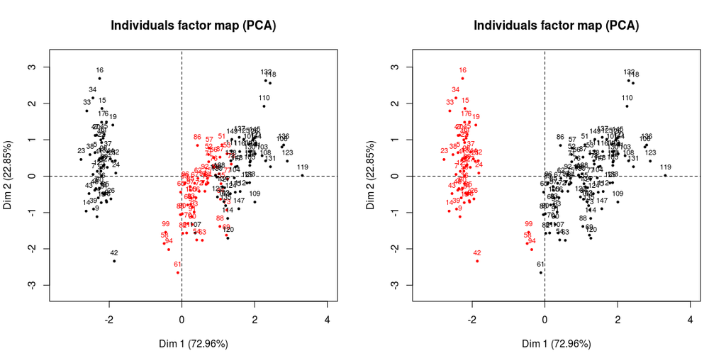

```r
par(mfrow=c(1,2))
plot(iris.scaled.acp, col.ind = variete2, cex  =0.7)
cluster.kmeans2 <- kmeans(mes.iris.scaled, center=2)$cluster
plot(iris.scaled.acp, col.ind = cluster.kmeans2, cex = 0.7)
```

```r
par(mfrow=c(1,1))
```

## Table de confusion et calcul de performances

```r
conf.kmeans <- table(variete2, cluster.kmeans2)
kable(conf.kmeans)
```

|  | 1 | 2 |
| --- | --- | --- |
| notVersicolor | 50 | 50 |
| versicolor | 47 | 3 |

```r
TP <- conf.kmeans[1,1]
FP <- conf.kmeans[1,2]
FN <- conf.kmeans[2,1]
TN <- conf.kmeans[2,2]
P <- TP + FN          # nb positif dans la réalité
N <- TN + FP          # nb négatif dans la réalité
FPrate <- FP / N      # = false alarm rate
Spe <- TN / N      # = spécificité
Sens <- recall <- TPrate <- TP / P      # = hit rate ou recall ou sensibilité ou coverage
PPV <- precision <- TP / (TP + FP)
accuracy <- (TP + TN) / (P + N)
F.measure <- 2 / (1/precision + 1/recall)
performance <- c(FPrate, TPrate, precision, recall, accuracy, F.measure, Spe, PPV)
names(performance) <- c("FPrate", "TPrate", "precision", "recall", "accuracy", "F.measure", "Spe", "PPV")
```

```r
kable(performance, digits=3)
```

|  | x |
| --- | --- |
| FPrate | 0.943 |
| TPrate | 0.515 |
| precision | 0.500 |
| recall | 0.515 |
| accuracy | 0.353 |
| F.measure | 0.508 |
| Spe | 0.057 |
| PPV | 0.500 |

```r
clues::adjustedRand(as.numeric(variete2), cluster.kmeans2)
```

```
      Rand         HA         MA         FM    Jaccard
0.53995526 0.07211421 0.07722223 0.57895580 0.40737752
```

# Pros et cons des différents algorithmes

| Algorithme | Pros | Cons |
| --- | --- | --- |
| **Hiérarchique** | L'arbre reflète la nature imbriquée de tous les sous-clusters | Complexité quadratique (mémoire et temps de calcul) $\rightarrow$ quadruple chaque fois qu'on double le nombre d'individus |
|  | Permet une visualisation couplée dendrogramme (groupes) + heatmap (profils individuels) |  |
|  | Choix a posteriori du nombre de clusters (élagage) |  |
| **K-means** | Rapide (linéaire en temps), peut traiter des jeux de données énormes (centaines de milliers de pics ChIP-seq) | Positions initiales des centres est aléatoire $\rightarrow$ résultats changent d'une exécution à l'autre |
|  |  | Distance euclidienne (pas appropriée pour transcriptome par exemple) |

Contact: anne.badel@univ-paris-diderot.fr